# Resultados de las Pruebas ICFES

Diego Lesmes

10/22/2020

# Primera parte

## Setup

Se guradan variales iniciales

```r
NOMBRE_APELLIDO = 'Diego Lesmes'
name_document = 'Datasets/ICFES 20192.csv'
nombre_excel = 'Datasets/ICFES 20192.TXT'
CARPETA_DE_STORAGE = 'Archivos Excel'
nombre_excel2 = 'Datasets/C600_2014_2019.csv'
```

## Librerias

En esta sección se cargan en el entorno las librerias que el proyecto necesita

```r
library(stringi) #Manipular texto y Expresiones Regulares
library(readxl) #Leer archivos de excel
library(stringr) #Manipular texto
library('zoo') #Indexar series de tiempo
library(dplyr) #Manpular dataframes
library(purrr) #Manipular vectores
library(tidyr) #Manpular dataframes
library(dplyr) #Manipular tablas
library(lubridate) #Manipular fechas
library(readr) #Leer archivos planos
```

# Comandos

# Importar los conjuntos de datos

Son funciones para leer los archivos planos, sirven para importar la data al entorno. la primer función lee la data “saber11 2019-2”, la cual esta separada por el simbolo de negación “¬”, es posible que tenga valores con cuatro comillas dobles seguidas ’"""“’, el texto tiene una codificación del tipo”latin1", es decir el conjunto de caracteres de los alfabetos del occidente de Europa definidos para ocupar un solo byte, Tiene datos faltantes, Ignora los espacios en blancos al principio y al final de cada dato Y se toman los tipos de variable spor defecto que tengan

```r
ICFES_20192 <- read_delim(nombre_excel,
                          delim = "¬", escape_double = FALSE, locale = locale(encoding = "LATIN1"),
                          na = "NA", trim_ws = TRUE, col_names = TRUE, col_types = cols(.default = col_character()))
```

# ICFES data

Es la reasignación del objeto “ICFES_20192” a través de la función lapply que recorre toda la matriz, dataframe o tibble aplicando la función indicada y arrojando el mismo tipo de objeto en este caso se sirve para borrar todos los caracteres de negación del la data “¬” y guardarlo en el mismo objeto o ubicación (ICFES_20192). Esto gracias a la función “gsub”, de la libreria por defecto, que reemplaza el patron que encuentre en todas las coincidencias por el valor indicado

```r
ICFES_20192[] <- lapply(ICFES_20192, gsub, pattern='¬', replacement='')
```

La sigiente linea es la reasiganción del dataframe “ICFES_20192” como el dataframe “ICFES_20192_2” cuyas diferencias ya se habian relacionado, sirve para quedarnos con un solo dataframe.

```r
ICFES_20192 = ICFES_20192_2
```

la siguiente linea es la asignación del vector “Lista_col” sirve para guardar en el los nombres de las columnas a usar en el ciclo posteriormente

```r
Lista_col = colnames(ICFES_20192)
```

Es un ciclo for que sirve para recorrer todas las columnas del dataframe “ICFES_20192”, cuyos nombres fueron guardados en el vector “lista_col” y a través de la función “iconv”, de la libreria por defecto, nos permite hacer la conversión de la codificación de los caracteres de “UTF-8” a “Latin1” ajustando el tamaño a ocupar.

```r
for (i in Lista_col)  {
  ICFES_20192[[i]] <- iconv(ICFES_20192[[i]],  to="latin1", sub="byte")
}
```

Es la conversión de la columna 4 del data frame a un formato de fecha en este caso dia mes año, sirve para cambiar el tipo de dato, gracias a la función as.DAte de la librería “Zoo”

```r
ICFES_20192[[4]] = as.Date(ICFES_20192[[4]], format = '%d-%m-%Y')
```

Es la reasignación del objeto “ICFES_20192” tres veces, a través de la función lapply que recorre toda la matriz, dataframe o tibble aplicando la función indicada y arrojando el mismo tipo de objeto en este caso se sirve para borrar todos los caracteres ‘’, ‘,’ y ’"“’ y guardarlo en el mismo objeto ICFES_20192. Esto gracias a la función”gsub", de la libreria por defecto, que reemplaza el patron que encuentre en todas las coincidencias por el valor indicado.

```r
ICFES_20192[] <- lapply(ICFES_20192, gsub, pattern='<ac>', replacement='')
ICFES_20192[] <- lapply(ICFES_20192, gsub, pattern=',', replacement='')
ICFES_20192[] <- lapply(ICFES_20192, gsub, pattern='"', replacement='')
ICFES_20192[] <- lapply(ICFES_20192, gsub, pattern='Â', replacement='')
```

es la asignación del vector “Lista_col” sirve para guardar en el los indices de algunas columnas a usar en el ciclo posteriormente

```r
Lista_col = c(61,64,67,70,73,74,76)
```

Es un ciclo for que sirve para recorrer todas las columnas del dataframe “ICFES_20192”, cuyos indices fueron guardados en el vector “lista_col”, y a través de la función “as.numeric”, de la libreria por defecto, nos permite hacer la conversión de estos campos al tipo de dato numerico

```r
for (i in Lista_col)  {
  ICFES_20192[[i]] <- as.numeric(ICFES_20192[[i]])
}
```

# Análisis de datos nulos

```r
table(is.na(ICFES_20192$'\xacPUNT_LECTURA_CRITICAÂ'))
```

```
##
## FALSE  TRUE
##  3684  4528
```

Yo agregaria este ciclo que me muestra el conteo de los valores nulos de cada na de las variables de interes

```r
for (i in Lista_col) {print(table(is.na(ICFES_20192[[i]])))}
```

```
##
## FALSE  TRUE
##  3684  4528
##
## FALSE  TRUE
##  5598  2614
##
## FALSE  TRUE
##  6988  1224
##
## FALSE  TRUE
##  7737   475
##
## FALSE  TRUE
##  8119    93
##
## FALSE  TRUE
##  8167    45
##
## FALSE  TRUE
##  7321   891
```

Es la reasignación de los campos del objeto ICFES_20192, a través de la combinación de las funciones lapply y gsub, ya comenetadas anteriormente en este saco sirve para editar los nombres de las columnas del objeto ICFES_20192 eliminando de ellos los patrones ‘’ y ‘Â’

```r
colnames(ICFES_20192) = lapply(colnames(ICFES_20192), gsub, pattern='\xac', replacement='')
colnames(ICFES_20192) = lapply(colnames(ICFES_20192), gsub, pattern='Â', replacement='')
```

Es la reasignación del objeto “ICFES_20192” como un subconjunto de si mismo, sirve para trabajar con un objeto mas pequeño y manejable en este caso el subconjunto corresponde al conjunto de datos filtrados por los registros no nulos del atributo “PUNT_LECTURA_CRITICA”.

```r
ICFES_20192 = subset(ICFES_20192, is.na(ICFES_20192$PUNT_LECTURA_CRITICA) == FALSE)
```

#Puntajes Promedios

Se crea un dataFrame “a” de tres campos con los promedios requeridos, sirve para ver un resumen de las puntuaciones en general

```r
a = data.frame('total' = (as.numeric(ICFES_20192$PUNT_C_NATURALES)
                          + as.numeric(ICFES_20192$PUNT_INGLES)
                          + as.numeric(ICFES_20192$PUNT_LECTURA_CRITICA)
                          + as.numeric(ICFES_20192$PUNT_SOCIALES_CIUDADANAS)  )/4,
               'total1' = (as.numeric(ICFES_20192$PUNT_C_NATURALES)
                           + as.numeric(ICFES_20192$PUNT_INGLES)
                           + as.numeric(ICFES_20192$PUNT_LECTURA_CRITICA)
                           + as.numeric(ICFES_20192$PUNT_SOCIALES_CIUDADANAS)
                           + as.numeric(ICFES_20192$PUNT_MATEMATICAS) )/5,
               'global' = as.numeric(ICFES_20192$PUNT_GLOBAL)/5)
```

La función hist, de la libreria por defecto, grafica los histogramas de la variable indicada, sirve para analizar el comportamiento de una variable y asi identificar su posible distribución, en este caso la variable “total” tenderia a tener una distribución Exponencial o geométrica, para lo cual es preciso validar esa hipotesis

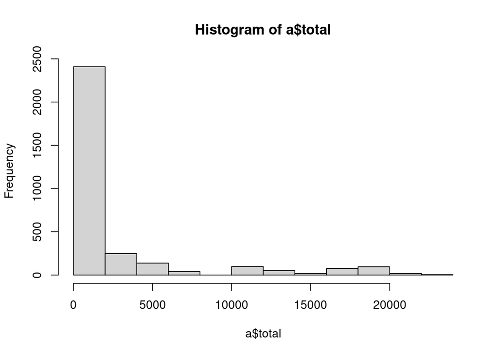

```r
hist(a$total)
```

en este caso la variable “PUNT_INGLES” tiene un outlier, que no permite visualizar su comportamiento.

Lo podemos ver en el resumen dado por la función “summary”, de los paquetes por defecto, la cual nos muestra para variable snumericas los extremos, mediana, media, rango intercuantil y los valores nulos.

```r
summary(ICFES_20192$PUNT_INGLES)
```

```
##     Min.  1st Qu.   Median     Mean  3rd Qu.     Max.     NA's
##     0.00     2.00     3.00    27.42    41.00 11001.00        2
```

El caso e la variable “PUNT_C_NATURALES” tiene un outlier tal que la función “hist” no lo grafica.

```r
summary(ICFES_20192$PUNT_C_NATURALES)
```

```
##    Min. 1st Qu.  Median    Mean 3rd Qu.    Max.    NA's
##     1.0     2.0     5.0   239.9    44.0 76834.0     443
```

Por lo cual se realiza una transformación logaritmica para manejar los outliers y asi poder graficar el histograma

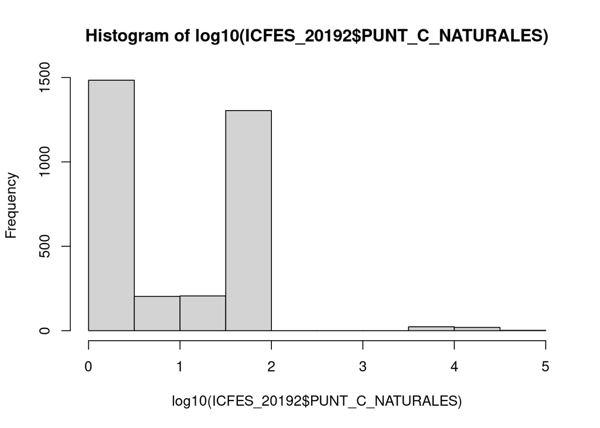

```r
hist(log10(ICFES_20192$PUNT_C_NATURALES))
```

```r
summary(log10(ICFES_20192$PUNT_C_NATURALES))
```

```
##    Min. 1st Qu.  Median    Mean 3rd Qu.    Max.    NA's
##   0.000   0.301   0.699   1.010   1.643   4.886     443
```

La funcón “summary” aplicado a un dataframe, nos arroja un resumen tal cual como ya se menciono pro organizado para cada variable

```r
summary(a)
```

```
##      total              total1            global
##  Min.   :    2.00   Min.   :    1.8   Min.   : 0.20
##  1st Qu.:   15.25   1st Qu.:   16.0   1st Qu.: 0.40
##  Median :   40.75   Median :   44.6   Median : 9.60
##  Mean   : 2372.04   Mean   : 2337.5   Mean   :19.64
##  3rd Qu.: 1406.00   3rd Qu.: 1754.7   3rd Qu.:40.70
##  Max.   :23524.50   Max.   :18345.6   Max.   :76.40
##  NA's   :484        NA's   :728       NA's   :885
```

# Guardar resultados

Es la función Write.table, del paquete “utils” instalado por defecto, que sirve para grabar en disco un objeto en el formato indicado. En este caso el dataframe final “ICFES_20192” en un archivo separado por comas llamado “ICFES_20192.csv”

```r
write.table(ICFES_20192, 'ICFES_20192.csv', row.names = F,sep = ',', col.names = F)
```

# Segunda parte

Es la lectura del archivo con la data del DANE. Gracias a la función read_delim explicada en la primer parte del código, se asigna al objeto “C600_2014_2019_Sede”

```r
C600_2014_2019_Sede <- read_delim(nombre_excel2,
                                  ",", escape_double = FALSE, locale = locale(encoding="LATIN1"),
                                  na = "NA", trim_ws = TRUE, col_names = T)
```

Se asigna al objeto C600 un subjunto de objeto “C600_2014_2019_Sede” que corresponde a los registros del año 2019

```r
C600 <- subset(C600_2014_2019_Sede, C600_2014_2019_Sede$PERIODO_ANIO == '2019')
```

Es la coerción del la columna “MUNI” del objeto “C600” gracias a la función “stri_trans_general” de la libreria stringi, que sirve para convertir del typo de dato Latin a ASCII el cual corresponde a los carácteres del inglés americano y ocupan un espacio de 7 bits. Adicionalmente los datos se guardan en mayuscula gracias a la función “toupper” del paquete por defecto de R.

```r
C600$MUNI =  toupper(stri_trans_general(C600$MUNI,"Latin-ASCII"))
```

Es la asignación del objeto ICFES_sel como un conjunto de columnas de la data resultante de la primera parte del código “ICFES_20192”. Sirve para utilizar los atributos que se necesita analizar solamente, esto gracias a la función “c()” que nos permite crear una lista y la función “Select” de la libreria “dplyr” como lo podemos ver en la notación utilizada, que seleccina las columnas indicadas en la lista.

```r
ICFES_sel = dplyr::select(ICFES_20192, c(4,11,13,15,22,24,40,41,43,48,50,53,54,47,64,67,70,76,78))
```

Configura la opción global para que R no use notación científica

```r
options(scipen=999)
```

Asignación del objeto “C600_sel” como un conjunto de columnas del objeto “C600”, la utilidad y explicación se dio en el comentario anterior

```r
C600_sel = dplyr::select(C600,  c(1,10,12,24,36,21,359,360,370))
```

Es la edición de los nombre de los campos del objeto creado en el codigo anterior, simplemente indicando el nombre a cada una de las columnas

```r
C600_sel = data.frame("SEDE_CODIGO" =  C600_sel[[1]],      "SEDE_NOMBRE"  = C600_sel[[2]]  ,
                      "SEDE_DIRECCION" =   C600_sel[[3]],    "LOCALIDAD" =  C600_sel[[4]],
                      "SECTOR_NOMBRE"  = C600_sel[[5]]  ,   "MUNI"   =    C600_sel[[6]],
                      "SEDETE_ELECTRICIDAD" = C600_sel[[7]], "TIENEELECTRICIDAD" = C600_sel[[8]],
                      "SEDETE_INTERNET" = C600_sel[[9]])
```

Es la creación una variable llamada “SEDETE_INTERNET_” al objeto “C600_sel” como una variable de typo booleano, para indicar si hay internet en la sede (1) o no (0).

```r
C600_sel$SEDETE_INTERNET_ = ifelse(C600_sel$SEDETE_INTERNET == 1,1,0)
```

Es la reasignación del objeto “C600_sel” como un conjunto de columnas de si mismo, con la función “Select”, ya explicada.En este caso selecciona todas las columnas con exepción de la 9°

```r
C600_sel = dplyr::select(C600_sel,-9)
```

Es la creación una variable llamada “SEDETE_ELECTRICIDA_” al objeto “C600_sel” como una variable de typo booleano, para indicar si hay energía eléctrica en la sede (1) o no (0).

```r
C600_sel$SEDETE_ELECTRICIDA_ = ifelse(C600_sel$SEDETE_ELECTRICIDA == 1,1,0)
```

Es la reasignación del objeto “C600_sel” como un conjunto de columnas de si mismo, con la función “Select”, ya explicada. En este caso selecciona todas las columnas las columnas con exepción de la 7°

```r
C600_sel = dplyr::select(C600_sel,-7)
```

Es la coerción de la variable “SEDE_CODIGO” del objeto “C600_sel” gracias a la función “as.character”. Sirve para definir el tipo de dato de esta variable como texto o cadena

```r
C600_sel$SEDE_CODIGO = as.character(C600_sel$SEDE_CODIGO)
```

Es la coerción de la variable “COLE_COD_DANE_SEDE” del objeto “ICFES_sel” gracias a la función “as.character”. Sirve para definir el tipo de dato de esta variable como texto o cadena.

```r
ICFES_sel$COLE_COD_DANE_SEDE   =   as.character(ICFES_sel$COLE_COD_DANE_SEDE)
```

Es una función del paquede “dplry” sirve para imprimir en la consola el traspuesto del objeto

```r
glimpse(ICFES_sel)
```

```
## Rows: 3,684
## Columns: 19
## $ ESTU_FECHANACIMIENTO          <chr> NA, NA, NA, NA, NA, NA, NA, NA, NA, NA, NA, NA, NA, NA, NA, NA, NA, NA, NA, NA, NA…
## $ ESTU_DEPTO_RESIDE             <chr> "SANTANDER", "BOLIVAR", "BOYACA", "BOGOTÃ", "VALLE", "SANTANDER", "CUNDINAMARCA", …
## $ ESTU_MCPIO_RESIDE             <chr> "BUCARAMANGA", "CARTAGENA DE INDIAS", "DUITAMA", "11", "CALI", "BUCARAMANGA", "SOA…
## $ FAMI_ESTRATOVIVIENDA          <chr> "", "Estrato 1", "Estrato 3", "<81> D.C.", "Estrato 4", "Estrato 3", "Estrato 3", …
## $ FAMI_TIENEINTERNET            <chr> "<ba>blico", "<ba>blico", "Si", "Trabaja en el hogar no trabaja o estudia", "Traba…
## $ FAMI_TIENECOMPUTADOR          <chr> "<b3>n al pÃ", "<b3>n al pÃ", "", "Si", "<a9>dico abogado ingeniero)", "Si", "Si",…
## $ COLE_COD_DANE_ESTABLECIMIENTO <chr> "", "Igual", "115238000698", "MÃ", "30 minutos o menos", "<a1>s de 3 horas", "0092…
## $ COLE_NOMBRE_ESTABLECIMIENTO   <chr> "0", "Entre 30 y 60 minutos", "COLEGIO GUILLERMO LEON VALENCIA", "<a1>s de 3 horas…
## $ COLE_NATURALEZA               <chr> "058206", "<a1>s de 3 horas", "OFICIAL", "<a1>s de 30 horas", "No", "709261", "MIX…
## $ COLE_NOMBRE_SEDE              <chr> "A", "INSTITUCION EDUCATIVA PROMOCION SOCIAL DE C/GENA.", "PRINCIPAL INTEGRADO", "…
## $ COLE_AREA_UBICACION           <chr> "TÃ<e2><80><b0>CNICO/ACADÃ<e2><80><b0>MICO", "OFICIAL", "URBANO", "A", "A", "TÃ<e2…
## $ COLE_MCPIO_UBICACION          <chr> "S", "TÃ<e2><80><b0>CNICO/ACADÃ<e2><80><b0>MICO", "DUITAMA", "111001094897", "3760…
## $ COLE_COD_DEPTO_UBICACION      <chr> "URBANO", "113001001719", "15", "CENT EDUC DIST PALERMO CEDIP", "CORPORACION EDUCA…
## $ COLE_COD_DANE_SEDE            <chr> "NO OFICIAL", "113001001719", "115238000698", "COLEGIO PALERMO  IEDIP  (IED)", "<8…
## $ PUNT_MATEMATICAS              <dbl> 68, 13001, 68, NA, 76001, 68, 3, NA, 20, NA, NA, 8, NA, 55, 51, 64, 8, 81, 2, 13, …
## $ PUNT_C_NATURALES              <dbl> 3, 13, 54, NA, 76, 3, 3, 17, 3, NA, NA, 3, NA, 31, 51, 54, 1, 2, 2, 13244, 2, 4, 8…
## $ PUNT_SOCIALES_CIUDADANAS      <dbl> 2, 4, 69, 11, 4, 3, 3, 19, 3, 48, 11, 3, 11, 31, 45, 62, 1, 3, 1, NA, 2, 4, 3, 64,…
## $ PUNT_GLOBAL                   <dbl> 3, 2, 319, 3, 3, 3, NA, 33, 2, 61, 4, 2, 2, 211, 254, 309, 1, 2, NA, 82, 1, 4, 2, …
## $ ESTU_INSE_INDIVIDUAL          <chr> "89", "99", "", "74", "96", "83", "78", "38", "45", "3", "83", "89", "32", "45.487…
```

## Cruce de datasets

se crea el dataframe ICFES_C600 con la funciń merge, sirve para crear la intersección de dos objetos, en este caso “ICFES_sel” y “C600_sel” a través de las columnas ‘COLE_COD_DANE_SEDE’ y ‘SEDE_CODIGO’ organizado por la columna de unió resultante evitando duplicados y completando los faltantes con nulos.

```r
ICFES_C600 <- merge(x = ICFES_sel, y = C600_sel, by.x = 'COLE_COD_DANE_SEDE', by.y = 'SEDE_CODIGO',
                    sort = TRUE, suffixes = c(".x",".y"), no.dups = T, all = F,
                    incomparables = NULL, fill= 'NA')
```

### Conteo

```r
table(ICFES_C600$FAMI_TIENEINTERNET)
```

```
##
##
##                                                                                   191
##                                                             <a1>quinas o conduce vehÃ
##                                                                                     5
##                                                                   <a9>cnica o tecnolÃ
##                                                                                    35
##                                                           <a9>dico abogado ingeniero)
##                                                                                     7
##                                                             <ad>culos (taxita chofer)
##                                                                                     9
##                   <b1>o (tiene pocos empleados o no tiene por ejemplo tienda papelerÃ
##                                                                                    37
##              <b1>o de un negocio grande tiene un cargo de nivel directivo o gerencial
##                                                                                     1
##                                                            <b1>o de un negocio pequeÃ
##                                                                                    17
##                                                                     <b3>gica completa
##                                                                                    22
##                                                                   <b3>gica incompleta
##                                                                                     5
##                                                                           <b3>n al pÃ
##                                                                                     3
##                                                            <b3>n profesional completa
##                                                                                    13
##                                                          <b3>n profesional incompleta
##                                                                                     2
##                                                                             <ba>blico
##                                                                                     6
##                                                                              EducaciÃ
##                                                                                     4
##                                                    Es agricultor pesquero o jornalero
##                                                                                     1
##                                                                               Es dueÃ
##                                                                                    25
##                                                                     Es operario de mÃ
##                                                                                    20
##                                                      Es vendedor o trabaja en atenciÃ
##                                                                                     9
##                                                                                    No
```

[output cut: 8 more lines]

```
##                                                                                     1
##                                                  Secundaria (Bachillerato) incompleta
##                                                                                     1
##                                                                                    Si
##                                                                                   211
##                                                                                    TÃ
##                                                                                     2
## Tiene un trabajo de tipo auxiliar administrativo (por ejemplo secretario o asistente)
##                                                                                     2
##               Trabaja como personal de limpieza mantenimiento seguridad o construcciÃ
##                                                                                     2
##                                              Trabaja como profesional (por ejemplo mÃ
##                                                                                    34
##                          Trabaja por cuenta propia (por ejemplo plomero electricista)
##                                                                                     7
```

```r
table(ICFES_C600$SEDETE_ELECTRICIDAD)
```

```
## < table of extent 0 >
```

# Modelo Inicial

```r
df = ICFES_C600 %>% dplyr::select(PUNT_GLOBAL , FAMI_ESTRATOVIVIENDA , FAMI_TIENEINTERNET
                                  , FAMI_TIENECOMPUTADOR , SEDETE_INTERNET_ , SEDETE_ELECTRICIDA_)
df = na.omit(df)
glimpse(df)
```

```
## Rows: 1,326
## Columns: 6
## $ PUNT_GLOBAL          <dbl> 245, 158, 3, 277, 188, 232, 215, 237, 197, 170, 216, 2, 2, 3, 204, 284, 1, 2, 2, 3, 223, 22…
## $ FAMI_ESTRATOVIVIENDA <chr> "Sin Estrato", "Estrato 5", "Estrato 3", "", "Estrato 1", "", "Estrato 2", "Estrato 2", "Es…
## $ FAMI_TIENEINTERNET   <chr> "Si", "Si", "<a9>cnica o tecnolÃ", "", "No", "", "Si", "Si", "No", "Si", "No", "Secundaria …
## $ FAMI_TIENECOMPUTADOR <chr> "Si", "No", "", "", "No", "", "Si", "No", "No", "Si", "No", "No sabe", "<ad>a etc", "Es ven…
## $ SEDETE_INTERNET_     <dbl> 1, 1, 1, 1, 1, 1, 1, 1, 1, 1, 1, 1, 1, 1, 1, 0, 1, 1, 1, 1, 1, 1, 1, 1, 1, 1, 1, 1, 1, 1, 1…
## $ SEDETE_ELECTRICIDA_  <dbl> 1, 1, 1, 1, 1, 1, 1, 1, 1, 1, 1, 1, 1, 1, 1, 1, 0, 1, 1, 1, 0, 0, 1, 1, 0, 1, 1, 1, 1, 1, 1…
```

```r
summary(glm(data = df, formula = PUNT_GLOBAL ~ . ))
```

```
##
## Call:
## glm(formula = PUNT_GLOBAL ~ ., data = df)
##
## Deviance Residuals:
##      Min        1Q    Median        3Q       Max
## -137.881   -23.996    -2.036    18.203   152.416
##
## Coefficients: (5 not defined because of singularities)
##                                                                                                            Estimate
## (Intercept)                                                                                                207.4011
## FAMI_ESTRATOVIVIENDA<81> D.C.                                                                               32.4081
## FAMI_ESTRATOVIVIENDA05001                                                                                   21.0775
## FAMI_ESTRATOVIVIENDA19698                                                                                   -7.0638
## FAMI_ESTRATOVIVIENDA44001                                                                                  -24.3691
## FAMI_ESTRATOVIVIENDA44560                                                                                    3.4218
## FAMI_ESTRATOVIVIENDA44847                                                                                 -221.9679
## FAMI_ESTRATOVIVIENDA76318                                                                                   76.4331
## FAMI_ESTRATOVIVIENDA91540                                                                                  -33.5323
## FAMI_ESTRATOVIVIENDAEstrato 1                                                                                7.1744
## FAMI_ESTRATOVIVIENDAEstrato 2                                                                                6.9173
## FAMI_ESTRATOVIVIENDAEstrato 3                                                                                4.5147
## FAMI_ESTRATOVIVIENDAEstrato 4                                                                               -8.7183
## FAMI_ESTRATOVIVIENDAEstrato 5                                                                              -13.2914
## FAMI_ESTRATOVIVIENDAEstrato 6                                                                              -14.4326
## FAMI_ESTRATOVIVIENDASin Estrato                                                                             -7.2700
## FAMI_TIENEINTERNET<a1>quinas o conduce vehÃ                                                               -223.4036
## FAMI_TIENEINTERNET<a9>cnica o tecnolÃ                                                                     -224.1827
## FAMI_TIENEINTERNET<a9>dico abogado ingeniero)                                                             -218.7972
## FAMI_TIENEINTERNET<ad>culos (taxita chofer)                                                               -221.7374
## FAMI_TIENEINTERNET<b1>o (tiene pocos empleados o no tiene por ejemplo tienda papelerÃ                     -225.6690
## FAMI_TIENEINTERNET<b1>o de un negocio grande tiene un cargo de nivel directivo o gerencial                -263.9550
## FAMI_TIENEINTERNET<b1>o de un negocio pequeÃ                                                              -215.3737
## FAMI_TIENEINTERNET<b3>gica completa                                                                       -219.9816
## FAMI_TIENEINTERNET<b3>gica incompleta                                                                     -225.1939
## FAMI_TIENEINTERNET<b3>n al pÃ                                                                             -229.9470
## FAMI_TIENEINTERNET<b3>n profesional completa                                                              -219.1483
## FAMI_TIENEINTERNET<b3>n profesional incompleta                                                            -228.6252
## FAMI_TIENEINTERNET<ba>blico                                                                               -213.2628
## FAMI_TIENEINTERNETEducaciÃ                                                                                -198.5207
```

[output cut: 339 more lines]

```
## FAMI_TIENECOMPUTADORTrabaja como profesional (por ejemplo mÃ
## FAMI_TIENECOMPUTADORTrabaja en el hogar no trabaja o estudia
## FAMI_TIENECOMPUTADORTrabaja por cuenta propia (por ejemplo plomero electricista)
## SEDETE_INTERNET_                                                                                          *
## SEDETE_ELECTRICIDA_
## ---
## Signif. codes:  0 '***' 0.001 '**' 0.01 '*' 0.05 '.' 0.1 ' ' 1
##
## (Dispersion parameter for gaussian family taken to be 1530.214)
##
##     Null deviance: 12320205  on 1325  degrees of freedom
## Residual deviance:  1923478  on 1257  degrees of freedom
## AIC: 13556
##
## Number of Fisher Scoring iterations: 2
```

```r
############## Familias sin internet y coles sin internet ###############
sin_internet = subset(ICFES_C600, ICFES_C600$FAMI_TIENEINTERNET == 'No' & ICFES_C600$TIENEELECTRICIDAD == 'No'  )
df = data.frame('a' = table(sin_internet$COLE_NOMBRE_ESTABLECIMIENTO))
table(sin_internet$COLE_MCPIO_UBICACION)
```

```
##
##                                      13074                                      23162
##                                          1                                          1
##                                      23672                                    ACEVEDO
##                                          1                                          2
##                                  AGUACHICA                                    AGUADAS
##                                          2                                          1
##                                     ALDANA                                  ALGARROBO
##                                          1                                          1
##                                  ALGECIRAS                                    ALMEIDA
##                                          1                                          1
##                          ALTOS DEL ROSARIO                                   ANAPOIMA
##                                          1                                          1
##                                      ANDES                               ANSERMANUEVO
##                                          3                                          1
##                       APARTADÃ<e2><80><9c>                                  AQUITANIA
##                                          1                                          1
##                                  ARACATACA                                  ARAUQUITA
##                                          1                                          2
##                                   ARBOLEDA                                  ARBOLETES
##                                          1                                          1
##                                    ARGELIA                                     ASTREA
##                                          1                                          2
##                                     AYAPEL                                     BALBOA
##                                          1                                          2
##                                  BARBACOAS                                    BARBOSA
##                                          2                                          1
##                               BARRANQUILLA                                      BELLO
##                                          3                                          1
##                                     BERBEO                               BUENAVENTURA
##                                          1                                          2
##                               BUENOS AIRES                                    BUESACO
##                                          1                                          1
##                             CÃ<c5><a1>CUTA                        CÃ<e2><80><9c>RDOBA
##                                          5                                          5
##                                 CAICEDONIA                                    CALAMAR
##                                          1                                          2
##                                    CALDONO                                       CALI
##                                          1                                          4
##                                     CALIMA                           CAMPO DE LA CRUZ
```

[output cut: 170 more lines]

```
##                                          2                                          2
##                                   VALENCIA                          VALLE DEL GUAMUEZ
##                                          1                                          2
##                                 VALLEDUPAR                                   VICTORIA
##                                          5                                          1
##                          VILLA DEL ROSARIO                    VILLAGARZÃ<e2><80><9c>N
##                                          2                                          1
##                                 VILLANUEVA                                 YACUANQUER
##                                          2                                          1
##                                    YARUMAL                        YOLOMBÃ<e2><80><9c>
##                                          1                                          1
##                          YONDÃ<e2><80><9c>                                      YOPAL
##                                          1                                          2
##                                   ZARAGOZA                              ZONA BANANERA
##                                          1                                          1
```

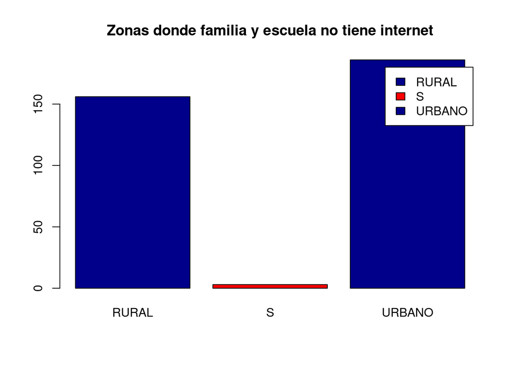

```r
barplot(table(sin_internet$COLE_AREA_UBICACION), main="Zonas donde familia y escuela no tiene internet",
        col=c("darkblue","red"),
        legend = rownames(table(sin_internet$COLE_AREA_UBICACION)))
```

```r
# ICFES_20192
# C600

A = paste0(NOMBRE_APELLIDO,"_",'C600_2014_2019_Sede.csv')
B = paste0(NOMBRE_APELLIDO,"_",'ICFES_sel_2019.csv')
#write.table(C600_2014_2019_Sede, A, row.names = F,sep = ',', col.names = F)
#write.table(ICFES_sel, B, row.names = F,sep = ',')

# ICFES_20192
# C600
```

# Modelo Propuesto

Efecto en el resultado global de tener Internet y Computador en la familia y colegio. Retomo el elemento df creado en la segunda parte en su definición lo bautizo “df_model”

```r
df_model = ICFES_C600 %>% dplyr::select(PUNT_GLOBAL , FAMI_ESTRATOVIVIENDA , FAMI_TIENEINTERNET
                                  , FAMI_TIENECOMPUTADOR , SEDETE_INTERNET_ , SEDETE_ELECTRICIDA_)
glimpse(df_model)
```

```
## Rows: 1,410
## Columns: 6
## $ PUNT_GLOBAL          <dbl> 245, 158, 3, 277, 188, 232, 215, 237, 197, 170, 216, 2, 2, 3, 204, 284, 1, 2, 2, 3, 223, 22…
## $ FAMI_ESTRATOVIVIENDA <chr> "Sin Estrato", "Estrato 5", "Estrato 3", "", "Estrato 1", "", "Estrato 2", "Estrato 2", "Es…
## $ FAMI_TIENEINTERNET   <chr> "Si", "Si", "<a9>cnica o tecnolÃ", "", "No", "", "Si", "Si", "No", "Si", "No", "Secundaria …
## $ FAMI_TIENECOMPUTADOR <chr> "Si", "No", "", "", "No", "", "Si", "No", "No", "Si", "No", "No sabe", "<ad>a etc", "Es ven…
## $ SEDETE_INTERNET_     <dbl> 1, 1, 1, 1, 1, 1, 1, 1, 1, 1, 1, 1, 1, 1, 1, 0, 1, 1, 1, 1, 1, 1, 1, 1, 1, 1, 1, 1, 1, 1, 1…
## $ SEDETE_ELECTRICIDA_  <dbl> 1, 1, 1, 1, 1, 1, 1, 1, 1, 1, 1, 1, 1, 1, 1, 1, 0, 1, 1, 1, 0, 0, 1, 1, 0, 1, 1, 1, 1, 1, 1…
```

```r
df_model <- subset(df_model, is.na(df_model$PUNT_GLOBAL) == FALSE)
```

Limpio las variables de interes para eliminar el ruido de la falta de validación de los datos, en especial de la “FAMI_TIENECOMPUTADOR”, “FAMI_TIENEINTERNET” “FAMI_ESTRATOVIVIENDA” para obtener variable booleanas y categorica respectivamente. Primero verifico que las opciones “Si” y “No” en las primeras dos variables sea una cantidad importante del total de registros, dando por hecho que las demás opciones son negativas.

```r
df_model %>% group_by(FAMI_TIENEINTERNET) %>%
  summarise("Cantidad" = n(), "Participación" = round(Cantidad/nrow(df_model)*100,1)) %>%
  filter(FAMI_TIENEINTERNET == "Si" | FAMI_TIENEINTERNET == "No") %>%
  knitr::kable()
```

| FAMI_TIENEINTERNET | Cantidad | Participación |
| --- | --- | --- |
| No | 686 | 50.7 |
| Si | 205 | 15.1 |

```r
df_model %>% group_by(FAMI_TIENECOMPUTADOR) %>%
  summarise("Cantidad" = n(), "Participación" = round(Cantidad/nrow(df_model)*100,1)) %>%
  filter(FAMI_TIENECOMPUTADOR == "Si" | FAMI_TIENECOMPUTADOR == "No") %>%
  knitr::kable()
```

| FAMI_TIENECOMPUTADOR | Cantidad | Participación |
| --- | --- | --- |
| No | 745 | 55.0 |
| Si | 225 | 16.6 |

Con esto veo que en cada variable las respuestas “que aplican” superan el 60% de la información, porlo cual procedo a redefinir las varibales.

```r
df_model <- df_model %>%
  mutate(FAMI_TIENECOMPUTADOR = ifelse(FAMI_TIENECOMPUTADOR == "Si",1,0),
         FAMI_TIENEINTERNET = ifelse(FAMI_TIENEINTERNET == "Si", 1, 0))
```

Reviso la variable “FAMI_ESTRATOVIVIENDA” y analizo su contenido, viendo que el 70% de la información se clasifica entre los estratos 0 a 6

```r
df_model %>% group_by(FAMI_ESTRATOVIVIENDA) %>%
  summarise("Cantidad" = n(), "Participación" = Cantidad/nrow(df_model)) %>%
  knitr::kable()
```

| FAMI_ESTRATOVIVIENDA | Cantidad | Participación |
| --- | --- | --- |
|  | 199 | 0.1469719 |
| <81> D.C. | 9 | 0.0066470 |
| 05001 | 3 | 0.0022157 |
| 18753 | 1 | 0.0007386 |
| 19698 | 1 | 0.0007386 |
| 27025 | 1 | 0.0007386 |
| 44001 | 1 | 0.0007386 |
| 44560 | 1 | 0.0007386 |
| 44847 | 1 | 0.0007386 |
| 76318 | 1 | 0.0007386 |
| 91540 | 1 | 0.0007386 |
| Estrato 1 | 558 | 0.4121123 |
| Estrato 2 | 322 | 0.2378139 |
| Estrato 3 | 122 | 0.0901034 |
| Estrato 4 | 41 | 0.0302806 |
| Estrato 5 | 21 | 0.0155096 |
| Estrato 6 | 7 | 0.0051699 |
| Sin Estrato | 64 | 0.0472674 |

Redefino las categorías de la variable de acuerdo a lo presentados

```r
df_model <- df_model %>%
  mutate(FAMI_ESTRATOVIVIENDA = ifelse(FAMI_ESTRATOVIVIENDA == "Estrato 1",1,
                                       ifelse(FAMI_ESTRATOVIVIENDA == "Estrato 2",2,
                                            ifelse(FAMI_ESTRATOVIVIENDA == "Estrato 3",3,
                                                 ifelse(FAMI_ESTRATOVIVIENDA == "Estrato 4",4,
                                                      ifelse(FAMI_ESTRATOVIVIENDA == "Estrato 5",5,
                                                           ifelse(FAMI_ESTRATOVIVIENDA == "Estrato 6",6,
                                                                ifelse(FAMI_ESTRATOVIVIENDA == "Sin Estrato",0,
                                                                     0)
                                                                )
                                                            )
                                                       )
                                                  )
                                             )
                                      )
         )
```

Reviso de nuevo la distribución.

```r
df_model %>% group_by(FAMI_ESTRATOVIVIENDA) %>%
  summarise("Cantidad" = n(), "Participación" = Cantidad/nrow(df_model)) %>%
  knitr::kable()
```

| FAMI_ESTRATOVIVIENDA | Cantidad | Participación |
| --- | --- | --- |
| 0 | 283 | 0.2090103 |
| 1 | 558 | 0.4121123 |
| 2 | 322 | 0.2378139 |
| 3 | 122 | 0.0901034 |
| 4 | 41 | 0.0302806 |
| 5 | 21 | 0.0155096 |
| 6 | 7 | 0.0051699 |

# análisis de correlaciones

Analizo la correlación entre las variables solicitadas, la cual me indica que entre las variables no se tiene una fuerte relación <|0.36|, que nos permita decir que la variación en alguna obedece a la variación en el puntaje_Global.

```r
cor(df_model)
```

```
##                      PUNT_GLOBAL FAMI_ESTRATOVIVIENDA FAMI_TIENEINTERNET FAMI_TIENECOMPUTADOR SEDETE_INTERNET_
## PUNT_GLOBAL            1.0000000          -0.35366202          0.2386130           0.20638437               NA
## FAMI_ESTRATOVIVIENDA  -0.3536620           1.00000000          0.1397112           0.03429315               NA
## FAMI_TIENEINTERNET     0.2386130           0.13971116          1.0000000           0.43692720               NA
## FAMI_TIENECOMPUTADOR   0.2063844           0.03429315          0.4369272           1.00000000               NA
## SEDETE_INTERNET_              NA                   NA                 NA                   NA                1
## SEDETE_ELECTRICIDA_           NA                   NA                 NA                   NA               NA
##                      SEDETE_ELECTRICIDA_
## PUNT_GLOBAL                           NA
## FAMI_ESTRATOVIVIENDA                  NA
## FAMI_TIENEINTERNET                    NA
## FAMI_TIENECOMPUTADOR                  NA
## SEDETE_INTERNET_                      NA
## SEDETE_ELECTRICIDA_                    1
```

Defino todas las variables categoricas

```r
df_model$FAMI_TIENEINTERNET <- as.factor(df_model$FAMI_TIENEINTERNET)
df_model$FAMI_TIENECOMPUTADOR <- as.factor(df_model$FAMI_TIENECOMPUTADOR)
df_model$SEDETE_INTERNET_ <- as.factor(df_model$SEDETE_INTERNET_)
df_model$SEDETE_ELECTRICIDA_ <- as.factor(df_model$SEDETE_ELECTRICIDA_)
df_model$FAMI_ESTRATOVIVIENDA <- as.factor(df_model$FAMI_ESTRATOVIVIENDA)
```

Verifico el tipo de variables

```r
str(df_model)
```

```
## 'data.frame':    1354 obs. of  6 variables:
##  $ PUNT_GLOBAL         : num  245 158 3 277 188 232 215 237 197 170 ...
##  $ FAMI_ESTRATOVIVIENDA: Factor w/ 7 levels "0","1","2","3",..: 1 6 4 1 2 1 3 3 2 3 ...
##  $ FAMI_TIENEINTERNET  : Factor w/ 2 levels "0","1": 2 2 1 1 1 1 2 2 1 2 ...
##  $ FAMI_TIENECOMPUTADOR: Factor w/ 2 levels "0","1": 2 1 1 1 1 1 2 1 1 2 ...
##  $ SEDETE_INTERNET_    : Factor w/ 2 levels "0","1": 2 2 2 2 2 2 2 2 2 2 ...
##  $ SEDETE_ELECTRICIDA_ : Factor w/ 2 levels "0","1": 2 2 2 2 2 2 2 2 2 2 ...
```

Grafico boxplot de las variables categoricas para confirmar el hecho detectado anteriormente.La librería “gridExtra” me permite unir las gráficas en una sola.

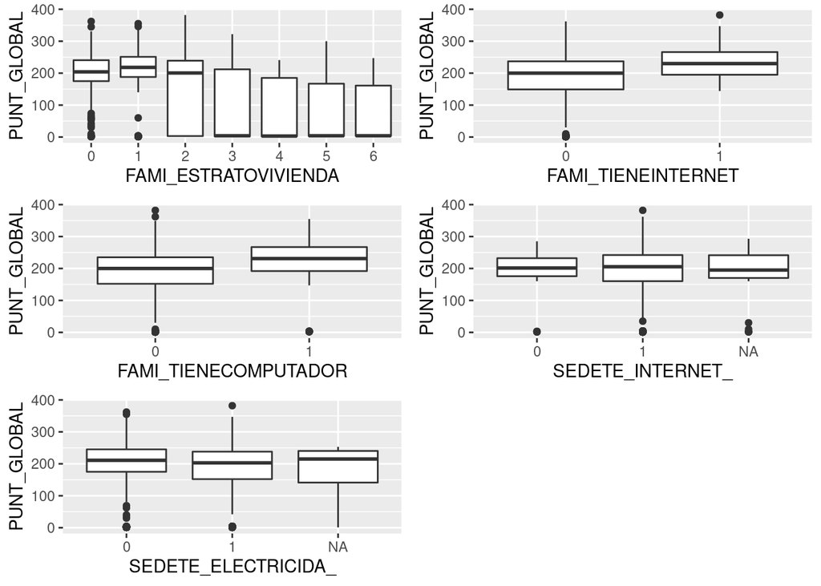

```r
G1 <- df_model %>% ggplot(aes(FAMI_ESTRATOVIVIENDA, PUNT_GLOBAL)) +
  geom_boxplot()
G2 <- df_model %>% ggplot(aes(FAMI_TIENEINTERNET, PUNT_GLOBAL)) +
  geom_boxplot()
G3 <- df_model %>% ggplot(aes(FAMI_TIENECOMPUTADOR, PUNT_GLOBAL)) +
  geom_boxplot()
G4 <- df_model %>% ggplot(aes(SEDETE_INTERNET_, PUNT_GLOBAL)) +
  geom_boxplot()
G5 <- df_model %>% ggplot(aes(SEDETE_ELECTRICIDA_, PUNT_GLOBAL)) +
  geom_boxplot()
blankPlot <- ggplot()+geom_blank(aes(1,1))+
  theme(plot.background = element_blank(),
        panel.grid.major = element_blank(),
        panel.grid.minor = element_blank(),
        panel.border = element_blank(),
        panel.background = element_blank(),
        axis.title.x = element_blank(),
        axis.title.y = element_blank(),
        axis.text.x = element_blank(),
        axis.text.y = element_blank(),
        axis.ticks = element_blank()
  )
library(gridExtra)
grid.arrange(G1, G2,G3, G4, G5,   blankPlot,
             ncol=2, nrow=3, widths=c(2,2), heights=c(3,3,3))
```

## Regresión lineal

Para hablar de algún modelo ilustrare a continuación el procedimiento para realizar una regresión lineal y validarla Realizo una partición de la información para poder veificar el error del modelo. Utilizo la librería caret para Machine Learning en R

```r
library(caret)
test_index <- createDataPartition(df_model$PUNT_GLOBAL, times = 1, p = 0.5, list = FALSE)
train_set <- df_model %>% slice(-test_index)
test_set <- df_model %>% slice(test_index)
```

Entreno el modelo con el conjunto de entrenamiento

```r
library(broom)
fit <- lm(formula = PUNT_GLOBAL ~ . ,data = train_set)
```

Podemos apreciar que el coficiente de determinación es bastante bajo, lo que inidca que no estamos tan lejos del modelo mas sencillo

```r
summary(fit)
```

```
##
## Call:
## lm(formula = PUNT_GLOBAL ~ ., data = train_set)
##
## Residuals:
##     Min      1Q  Median      3Q     Max
## -213.09  -43.08   11.58   57.44  200.14
##
## Coefficients:
##                        Estimate Std. Error t value             Pr(>|t|)
## (Intercept)            216.4534    15.4113  14.045 < 0.0000000000000002 ***
## FAMI_ESTRATOVIVIENDA1   -0.3655     8.9764  -0.041               0.9675
## FAMI_ESTRATOVIVIENDA2  -44.7360    10.3701  -4.314  0.00001854294111452 ***
## FAMI_ESTRATOVIVIENDA3 -106.4310    13.2377  -8.040  0.00000000000000428 ***
## FAMI_ESTRATOVIVIENDA4 -154.4711    21.3495  -7.235  0.00000000000131856 ***
## FAMI_ESTRATOVIVIENDA5 -136.1884    27.9108  -4.879  0.00000134132120637 ***
## FAMI_ESTRATOVIVIENDA6 -191.0965    60.6368  -3.151               0.0017 **
## FAMI_TIENEINTERNET1     47.9578    10.7581   4.458  0.00000975768934233 ***
## FAMI_TIENECOMPUTADOR1   42.9413    10.0573   4.270  0.00002251173141213 ***
## SEDETE_INTERNET_1      -22.8568    13.9266  -1.641               0.1012
## SEDETE_ELECTRICIDA_1    -4.9829     6.7297  -0.740               0.4593
## ---
## Signif. codes:  0 '***' 0.001 '**' 0.01 '*' 0.05 '.' 0.1 ' ' 1
##
## Residual standard error: 84.93 on 647 degrees of freedom
##   (18 observations deleted due to missingness)
## Multiple R-squared:  0.2588, Adjusted R-squared:  0.2474
## F-statistic:  22.6 on 10 and 647 DF,  p-value: < 0.00000000000000022
```

Podemos apreciar los coeficientes o pendientes para cada una de las variables y su respectivo p_value

```r
round(data.frame(slope = fit$coefficients,
           se = summary(fit)$coefficients[,2],
           p_value = summary(fit)$coefficient[,4]),2)%>%
  knitr::kable()
```

|  | slope | se | p_value |
| --- | --- | --- | --- |
| (Intercept) | 216.45 | 15.41 | 0.00 |
| FAMI_ESTRATOVIVIENDA1 | -0.37 | 8.98 | 0.97 |
| FAMI_ESTRATOVIVIENDA2 | -44.74 | 10.37 | 0.00 |
| FAMI_ESTRATOVIVIENDA3 | -106.43 | 13.24 | 0.00 |
| FAMI_ESTRATOVIVIENDA4 | -154.47 | 21.35 | 0.00 |
| FAMI_ESTRATOVIVIENDA5 | -136.19 | 27.91 | 0.00 |
| FAMI_ESTRATOVIVIENDA6 | -191.10 | 60.64 | 0.00 |
| FAMI_TIENEINTERNET1 | 47.96 | 10.76 | 0.00 |
| FAMI_TIENECOMPUTADOR1 | 42.94 | 10.06 | 0.00 |
| SEDETE_INTERNET_1 | -22.86 | 13.93 | 0.10 |
| SEDETE_ELECTRICIDA_1 | -4.98 | 6.73 | 0.46 |

Realizamos las predicciones

```r
y_hat <- predict(fit, type = "response")
#plot(y_hat, test_set$PUNT_GLOBAL)
RMSE(test_set$PUNT_GLOBAL, y_hat)
```

```
## [1] 107.7484
```